# tPRiors-dynamic-report

20 October, 2022

## General information

This report has automatically been generated by the shiny web-application tPRiors as an R Markdown document based on your data input and prior selection. The web-application can be found at https://publicandonehealth.shinyapps.io/tPRiors. We advice users that after observing the results of this report to avoid re-updating their prior beliefs to avoid hampering the credibility of these results.

The following section describes your input. During set-up the user assumed that:

1. Single modelled,
2. No, zero prevalence was modeled,
3. between the Apparent and True prevalence the Apparent prevalence was modelled and
4. (the) Mean was used to elicitate prior knowledge.

## The elicited prior

```
## [1] "Summary of Apparent prevalence Beta(6.81,1.3) prior"
```

```
##    Min. 1st Qu.  Median    Mean 3rd Qu.    Max.
##  0.1833  0.7714  0.8679  0.8399  0.9340  0.9998
```

————————————————————————

## The data

A summary of the input data is provided below

```
## [1] "The sample size was set equal to 500, while the positive subjects were set equal to 250"
```

```
## [1] "The observed (apparent) prevalence was equal to 50%"
```

## The model

```
## [1] "Summary of posterior prevalence"
```

```
##    Min. 1st Qu.  Median    Mean 3rd Qu.    Max.
##  0.4248  0.4898  0.5044  0.5050  0.5202  0.5756
```

```
## [1] "Quantiles of posterior prevalence"
```

```
##      0%      1%    2.5%     10%     20%     50%     80%     90%   97.5%     99%    100%
## 0.42482 0.45443 0.46262 0.47749 0.48700 0.50442 0.52402 0.53287 0.54731 0.55543 0.57557
```

```
## [1] "Probability that the posterior prevalence is higher than 0.05 equals to"
```

```
## [1] 1
```

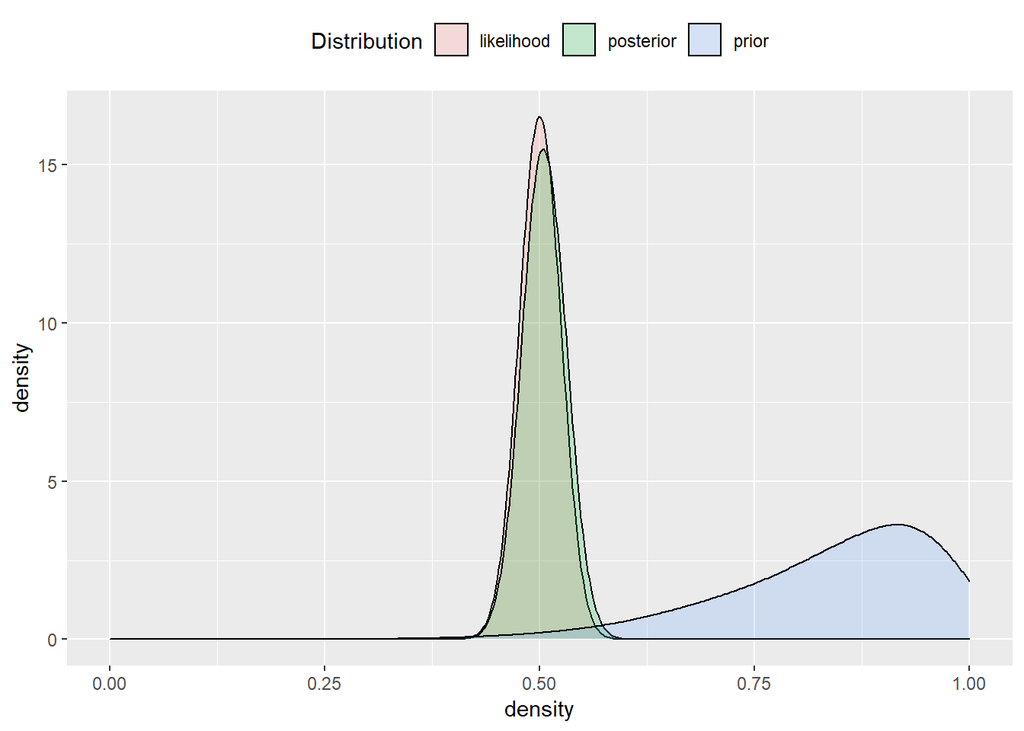

```
##    Min. 1st Qu.  Median    Mean 3rd Qu.    Max.
##  0.4248  0.4898  0.5044  0.5050  0.5202  0.5756
```

## Predictions

Predictive distribution of $y$ for a single new study with $n=100$.

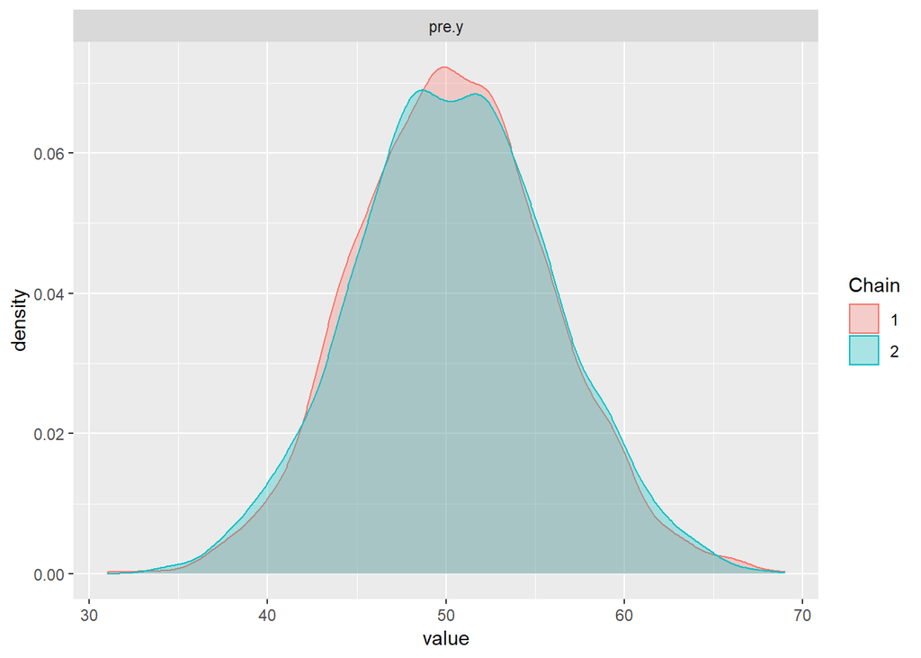

## Diagnostics

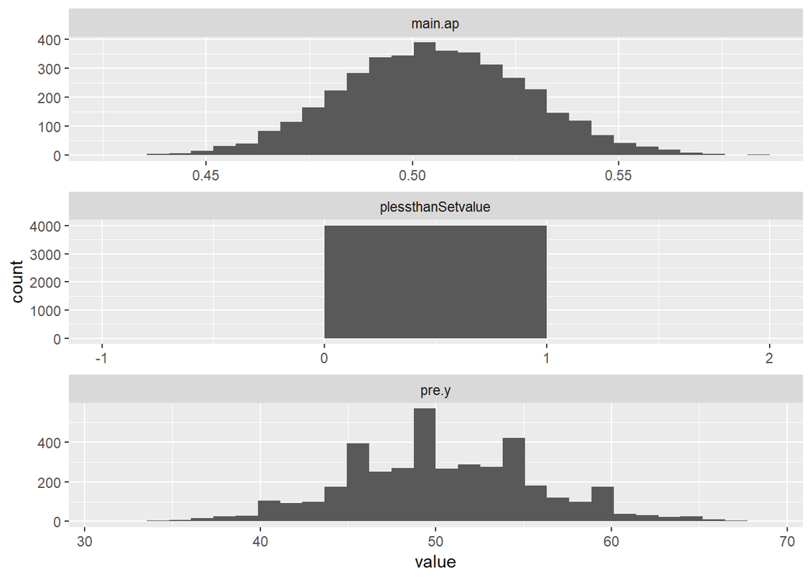

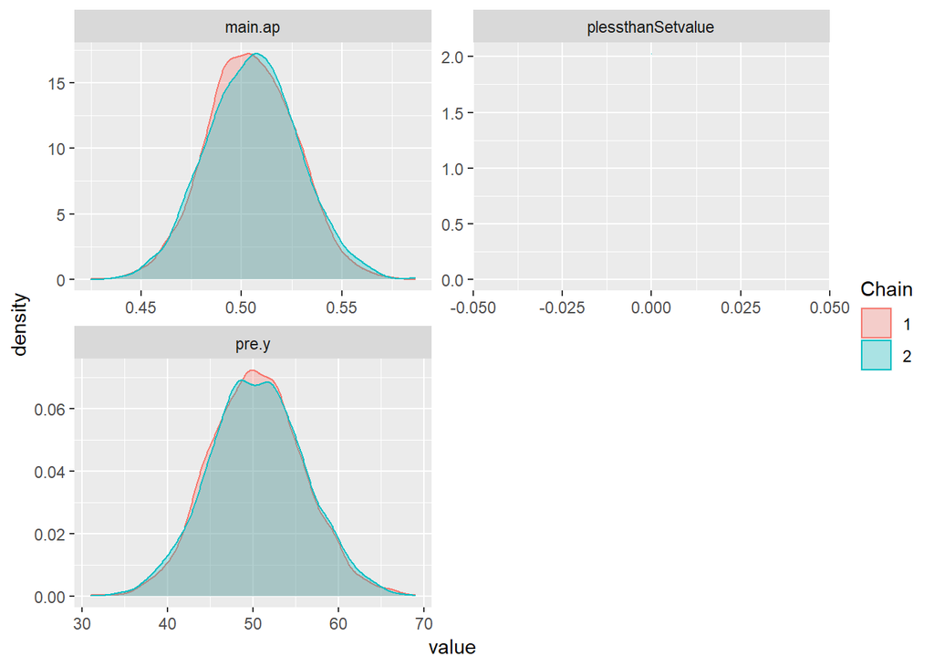

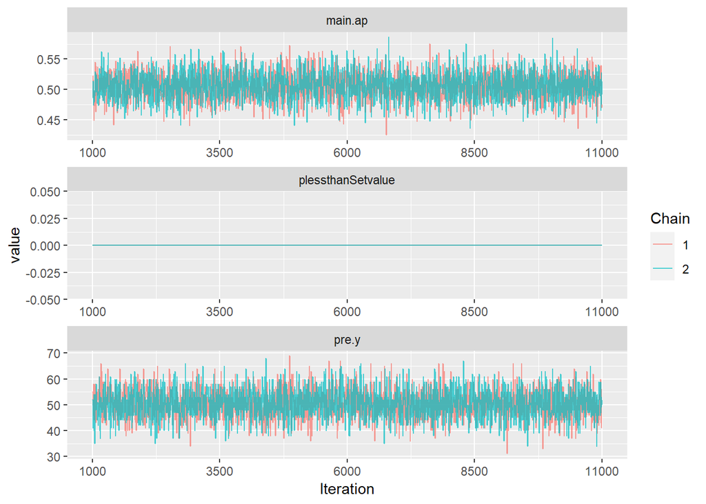

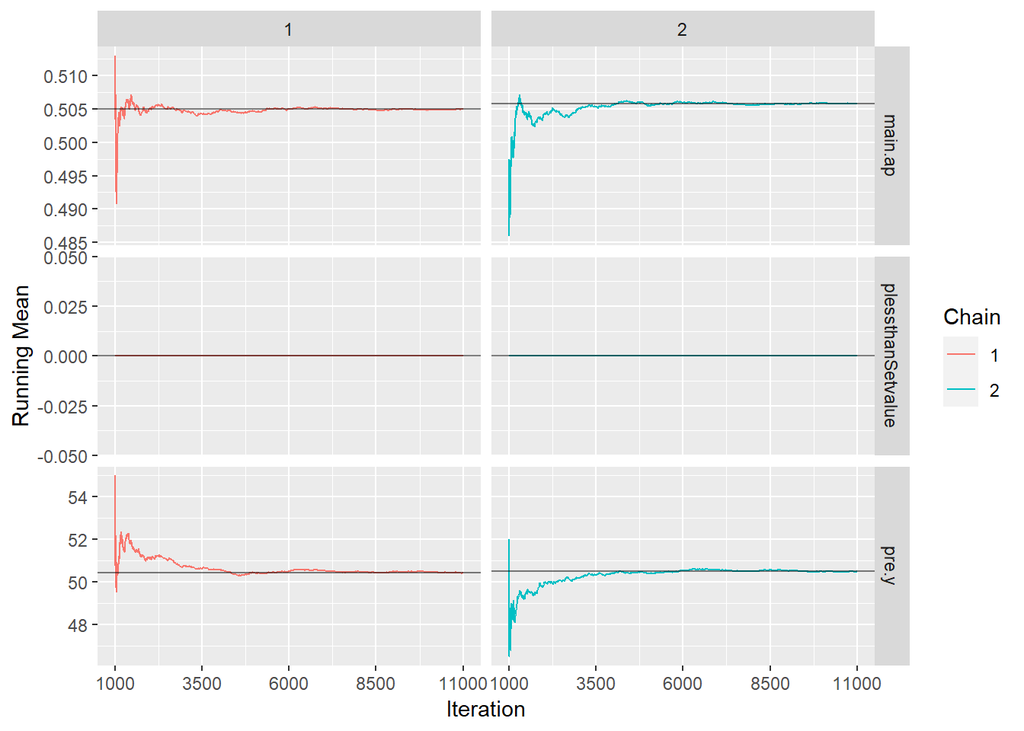

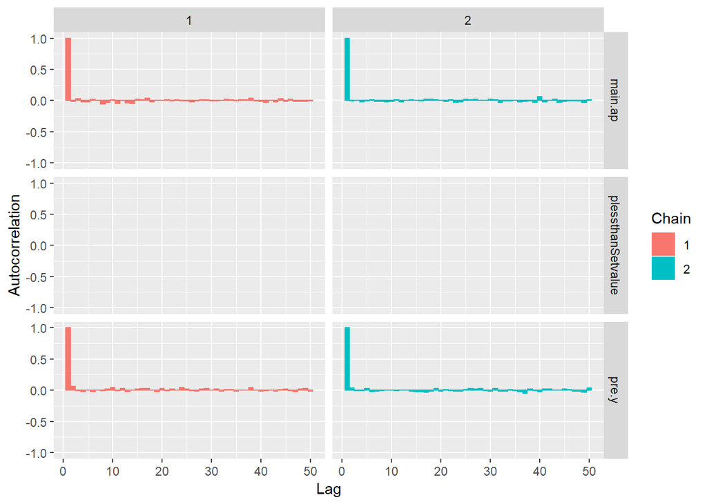

End of tPRiors report.

# Instructions for using the resulted .rData files

# Working with the <Model.mcmc> object

The Model.mcmc object contains MCMC samples produced by the current Bayesian analysis set-up. When loaded in R the user can perform further descriptive analysis and check more diagnostics, which is especially important in multiple populations where the number of parameters becomes very large and inference may become unstable. We provide a number of potentially useful descriptive and diagnostic plots from the CODA package alone or in combination with the ggmcmc R package.

traceplot(Model1.mcmc)

autocorr.plot(Model1.mcmc)

geweke.plot(Model1.mcmc)

When working with multiple population models that contain many parameters it can be convinient to use the family option of the ggs function group. First load the data files, then install and load the ggmcmc library. In the case of multiple populations if family=“main” then, only main parameters are being plotted, if family=“sub” then only study parameters are selected, while if family=“pre” then predictive parameters are selected and returned. Some examples are provided below.

S2<-ggs(Model1.mcmc)

ggs_histogram(S2,family = “main”) # Histograms (Main)

ggs_density(S2,family = “main”) # Density plots for main parameters

ggs_density(S2,family = “sub”) # Density plots for study prevalences

ggs_density(S2,family = “pre”) # Density plots for predictive parameters

ggs_traceplot(S2,family = “main”) # Trace plots (Main)

ggs_running(S2,family = “main”) # Running means plots (Main)

ggs_compare_partial(S2,family = “main”) # Partial chain comparison plots (Main)

ggs_autocorrelation(S2,family = “main”) # Autocorrelation plots (Main)